# Análise de dados utilizando parcela subdividida

22/09/2021

## Introdução

Será analisado um banco de dados fictício de um experimento em blocos casualizados, onde há 3 espécies diferentes de cultivares (CULT1, CULT2 e CULT3), 4 tipos diferentes de irrigação (irrigacao1,irrigacao2,irrigacao3 e irrigacao4) com 3 repetições em blocos casualizados.

## Objetivo:

Comparar se há diferença significativa de produção no plantio de diferentes espécies de cultivares e diferentes tipos de irrigação.

## Metodologia

Para esta análise será utilizado o pacote `ExpDes.pt` para obter a ANOVA e demais resultados.

## Visualização dos 5 primeiros dados do Banco de Dados

| Cultivares | Irrigacao | Bloco | Prod |
| --- | --- | --- | --- |
| CULT1 | irrigacao1 | 1 | 66 |
| CULT1 | irrigacao1 | 2 | 64 |
| CULT1 | irrigacao1 | 3 | 76 |
| CULT1 | irrigacao2 | 1 | 70 |
| CULT1 | irrigacao2 | 2 | 67 |

## Visualização do Experimento

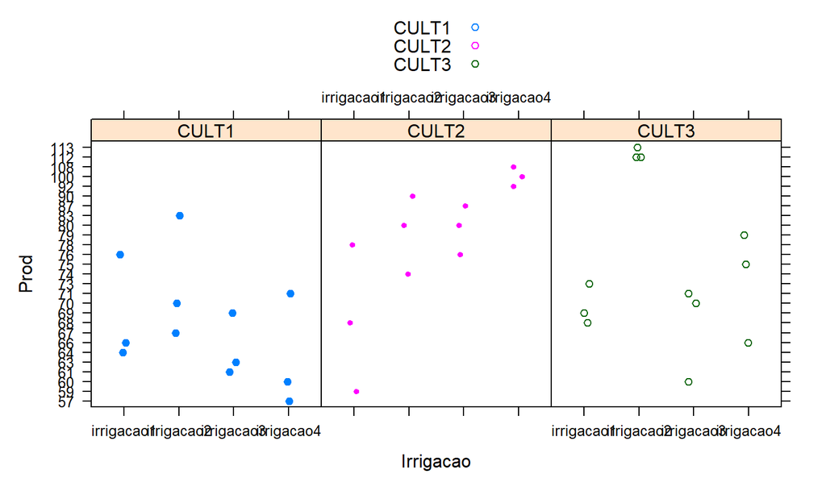

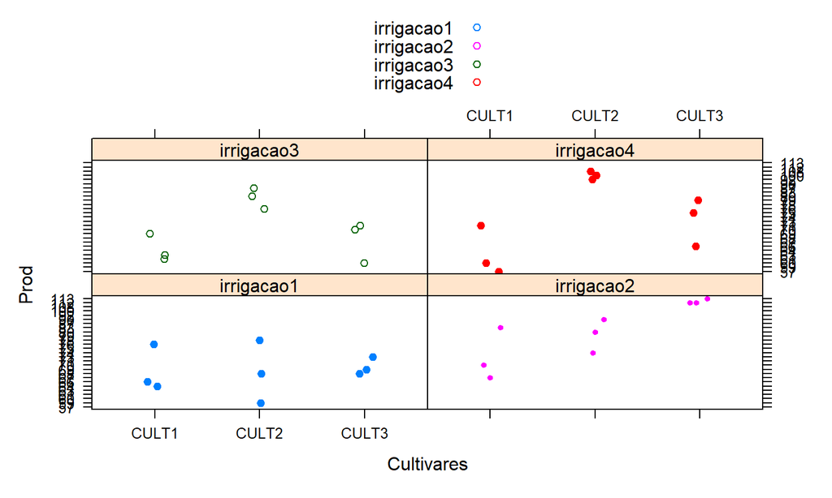

## Teste de Hipóteses

### Hipóteses que queremos testar:

H0: Não há diferença entre as irrigações em relação a produtividade.  
H1: Há influência da irrigação na produtividade.

H0:Há diferença entre os blocos.  
H1: Não há diferença entre os blocos.

H0: Não há diferença entre os cultivares na produtividade.  
H1: Há diferença dos cultivares na produção.

H0: A interação entre os cultivares e irrigação não é significativa.  
H1: A interação é significativa.

## Análise de Resíduos

```
##                      Df Sum Sq Mean Sq F value   Pr(>F)
## Cultivares            2   1687   843.4  39.186 8.17e-08 ***
## Irrigacao             3   2245   748.3  34.767 2.49e-08 ***
## Cultivares:Irrigacao  6   3564   593.9  27.596 6.33e-09 ***
## Cultivares:Bloco      3    597   199.1   9.252 0.000425 ***
## Residuals            21    452    21.5
## ---
## Signif. codes:  0 '***' 0.001 '**' 0.01 '*' 0.05 '.' 0.1 ' ' 1
```

## Gráfico

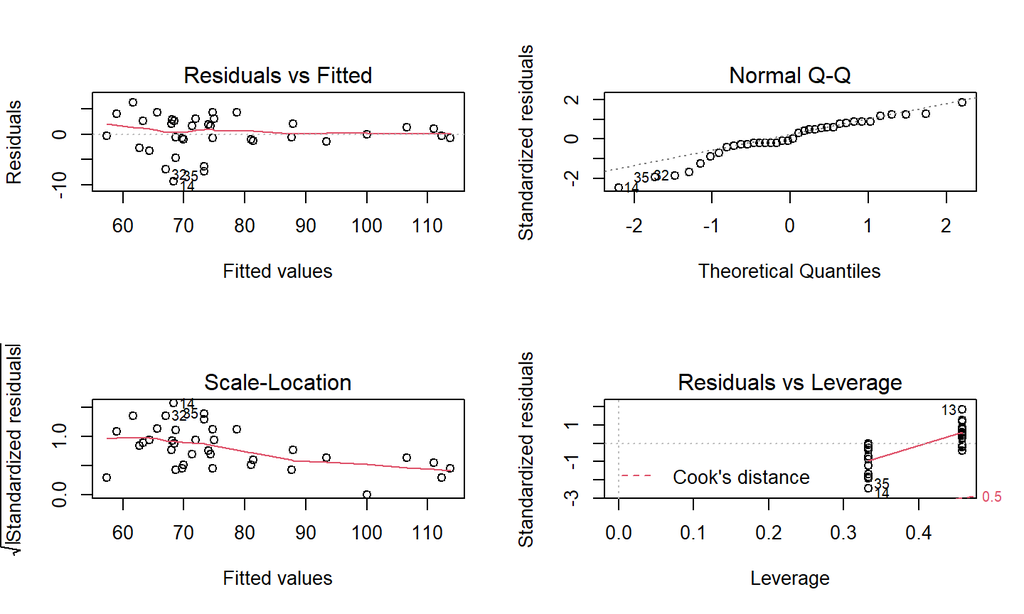

## Teste de Normalidade

```
##
##  Shapiro-Wilk normality test
##
## data:  dados.avb$residuals
## W = 0.93821, p-value = 0.0447
```

## Boxplot

### irrigação

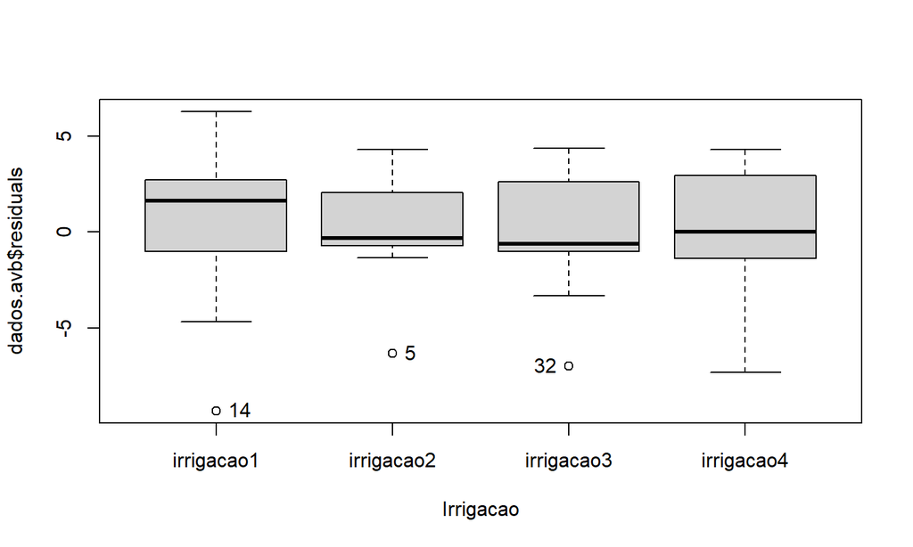

```
## [1] "14" "5"  "32"
```

## Cultivar

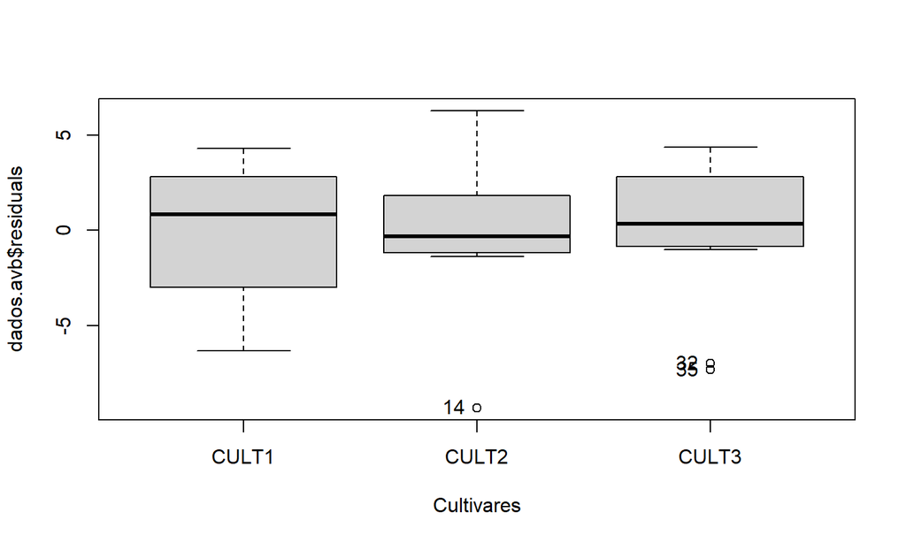

```
## [1] "14" "32" "35"
```

## Cultivar x Irrigação

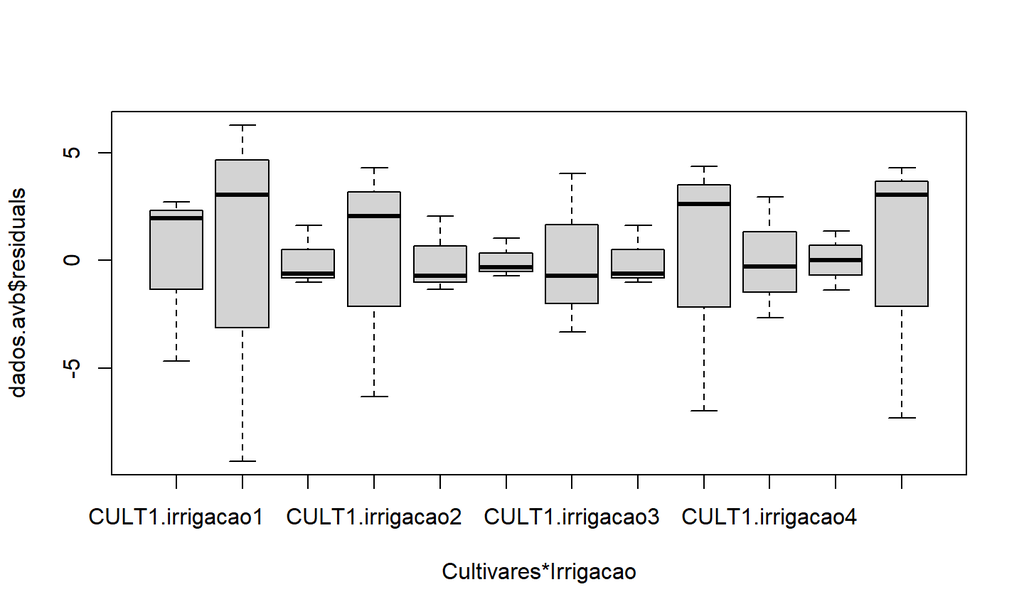

## Quadro da análise de variância

[output not shown]

## Teste Tukey

### Cultivares dentro de Irrigação - irrigacao 2

```
Grupos Tratamentos  Medias
a       CULT3       112.3333
b       CULT2       81.33333
b       CULT1       73.33333
```

## Cultivares dentro de Irrigação - irrigacao 3

```
Grupos Tratamentos Medias
a      CULT2         81
b      CULT3         67
b      CULT1         64.33333
```

## Cultivares dentro de Irrigação - irrigacao 4

```
Grupos Tratamentos  Medias
a       CULT2        100
 b      CULT3        73.33333
  c       CULT1          62.66667
```

## Irrigação dentro de Cultivares - CULT1

```
Grupos Tratamentos Medias
a    irrigacao2      73.33333
ab   irrigacao1      68.66667
 b   irrigacao3      64.33333
 b   irrigacao4      62.66667
```

## Irrigação dentro de Cultivares - CULT2

```
Grupos Tratamentos   Medias
a      irrigacao4    100
 b     irrigacao2    81.33333
 b     irrigacao3    81
  c      irrigacao1      68.33333
```

## Irrigação dentro de Cultivares - CULT3

```
Grupos Tratamentos Medias
 a    irrigacao2     112.3333
 b    irrigacao4     73.33333
 b    irrigacao1     70
 b    irrigacao3     67
```

## Conclusão

Observa-se que as interações foram significativas na análise de variância.  
Analisando os desdobramentos temos que:  
Dentre os 3 Cultivares, o Cultivar 2 apresenta melhores resultados em relação às Irrigações.  
Dentre as 4 Irrigações, a Irrigação 2 apresenta melhores resultados em relação aos Cultivares.